# 1. Computing with Language: Texts and Words

## 1.1 Getting Started with Python

please refer to my course website for Programming Basics:

https://zhangjianzhang.github.io/programming_basics/

## 1. 2 Getting Started with NLTK

```python
import nltk
```

```python
nltk.download()
```

```
showing info https://raw.githubusercontent.com/nltk/nltk_data/gh-pages/index.xml
```

```
True
```

```python
# Download the text data needed in this chapter
# nltk.download('gutenberg')
# nltk.download('nps_chat')
# nltk.download('inaugural')
```

[output not shown]

```python
from nltk.book import *
```

```
*** Introductory Examples for the NLTK Book ***
Loading text1, ..., text9 and sent1, ..., sent9
Type the name of the text or sentence to view it.
Type: 'texts()' or 'sents()' to list the materials.
text1: Moby Dick by Herman Melville 1851
text2: Sense and Sensibility by Jane Austen 1811
text3: The Book of Genesis
text4: Inaugural Address Corpus
text5: Chat Corpus
text6: Monty Python and the Holy Grail
text7: Wall Street Journal
text8: Personals Corpus
text9: The Man Who Was Thursday by G . K . Chesterton 1908
```

```python
text1
```

```
<Text: Moby Dick by Herman Melville 1851>
```

```python
text9
```

```
<Text: The Man Who Was Thursday by G . K . Chesterton 1908>
```

## 1.3 Searching Text

```python
text1.concordance("monstrous")
```

```
Displaying 11 of 11 matches:
ong the former , one was of a most monstrous size . ... This came towards us ,
ON OF THE PSALMS . " Touching that monstrous bulk of the whale or ork we have r
ll over with a heathenish array of monstrous clubs and spears . Some were thick
d as you gazed , and wondered what monstrous cannibal and savage could ever hav
that has survived the flood ; most monstrous and most mountainous ! That Himmal
they might scout at Moby Dick as a monstrous fable , or still worse and more de
th of Radney .'" CHAPTER 55 Of the Monstrous Pictures of Whales . I shall ere l
ing Scenes . In connexion with the monstrous pictures of whales , I am strongly
ere to enter upon those still more monstrous stories of them which are to be fo
ght have been rummaged out of this monstrous cabinet there is no telling . But
of Whale - Bones ; for Whales of a monstrous size are oftentimes cast up dead u
```

### *Your Turn*

Try searching for other words.

```python
text1.similar("monstrous")
```

```
true contemptible christian abundant few part mean careful puzzled
mystifying passing curious loving wise doleful gamesome singular
delightfully perilous fearless
```

```python
text2.similar("monstrous")
```

```
very so exceedingly heartily a as good great extremely remarkably
sweet vast amazingly
```

```python
text2.common_contexts(["monstrous", "very"])
```

```
am_glad a_pretty a_lucky is_pretty be_glad
```

### *Your Turn*

Pick another pair of words and compare their usage in two different texts, using the similar() and common_contexts() functions.

### *思考题*

假如你要写一篇大数据处理的英文论文，虽然你过了四六级，但是学术写作仍是小白，你可以像上面一样构建一个相关论文数据库，并在写作时查询某个词在该领域的论文写作中的常见用法，基本思路如下：

- 收集大数据处理领域（或者某个子领域）的高水平英文学术论文
- 将收集到的论文转化为NLTK支持的文本数据库
- 使用上述功能辅助你的英文写作

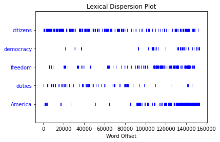

```python
text4.dispersion_plot(["citizens", "democracy", "freedom", "duties", "America"])
```

You can also plot the frequency of word usage through time using https://books.google.com/ngrams

```python
text3.generate()
```

```
Building ngram index...
```

```
laid by her , and said unto Cain , Where art thou , and said , Go to ,
I will not do it for ten ' s sons ; we dreamed each man according to
their generatio the firstborn said unto Laban , Because I said , Nay ,
but Sarah shall her name be . , duke Elah , duke Shobal , and Akan .
and looked upon my affliction . Bashemath Ishmael ' s blood , but Isra
for as a prince hast thou found of all the cattle in the valley , and
the wo The
```

```
"laid by her , and said unto Cain , Where art thou , and said , Go to ,\nI will not do it for ten ' s sons ; we dreamed each man according to\ntheir generatio the firstborn said unto Laban , Because I said , Nay ,\nbut Sarah shall her name be . , duke Elah , duke Shobal , and Akan .\nand looked upon…
```

```python
text1.generate()
```

```
Building ngram index...
```

```
long , from one to the top - mast , and no coffin and went out a sea
captain -- this peaking of the whales . , so as to preserve all his
might had in former years abounding with them , they toil with their
lances , strange tales of Southern whaling . at once the bravest
Indians he was , after in vain strove to pierce the profundity . ?
then ?" a levelled flame of pale , And give no chance , watch him ;
though the line , it is to be gainsaid . have been
```

```
'long , from one to the top - mast , and no coffin and went out a sea\ncaptain -- this peaking of the whales . , so as to preserve all his\nmight had in former years abounding with them , they toil with their\nlances , strange tales of Southern whaling . at once the bravest\nIndians he was , after i…
```

### *思考题*

假如你构建了一个某作家作品集的语料库，也可以用上述方法尝试生成类似该作家文风的随机文本

```python
len(text3)
```

```
44764
```

```python
sorted(set(text3))
```

```
['!',
 "'",
 '(',
 ')',
 ',',
 ',)',
 '.',
 '.)',
 ':',
 ';',
 ';)',
 '?',
 '?)',
 'A',
 'Abel',
 'Abelmizraim',
 'Abidah',
 'Abide',
 'Abimael',
 'Abimelech',
 'Abr',
 'Abrah',
 'Abraham',
 'Abram',
 'Accad',
 'Achbor',
 'Adah',
 'Adam',
 'Adbeel',
 'Admah',
 'Adullamite',
 'After',
 'Aholibamah',
 'Ahuzzath',
 'Ajah',
 'Akan',
 'All',
 'Allonbachuth',
 'Almighty',
 'Almodad',
```

[output cut: 946 more lines]

```
 'clean',
 'clear',
 'cleave',
 'clo',
 'closed',
 'clothed',
 'clothes',
 'cloud',
 'clusters',
 'co',
 'coat',
 'coats',
 'coffin',
 'cold',
 ...]
```

```python
len(set(text3))
```

```
2789
```

```python
len(set(text3)) / len(text3)
```

```
0.06230453042623537
```

```python
text3.count("smote")
```

```
5
```

```python
100 * text4.count('a') / len(text4)
```

```
1.457806031353621
```

```python
def lexical_diversity(text):
    return len(set(text)) / len(text)

def percentage(count, total):
    return 100 * count / total
```

```python
lexical_diversity(text3)
```

```
0.06230453042623537
```

```python
lexical_diversity(text5)
```

```
0.13477005109975562
```

```python
percentage(4, 5)
```

```
80.0
```

```python
percentage(text4.count('a'), len(text4))
```

```
1.457806031353621
```

# 2. A Closer Look at Python: Texts as Lists of Words

## 2.1 Lists

```python
sent1 = ['Call', 'me', 'Ishmael', '.']
```

```python
sent1
```

```
['Call', 'me', 'Ishmael', '.']
```

```python
len(sent1)
```

```
4
```

```python
lexical_diversity(sent1)
```

```
1.0
```

```python
sent2
```

```
['The',
 'family',
 'of',
 'Dashwood',
 'had',
 'long',
 'been',
 'settled',
 'in',
 'Sussex',
 '.']
```

```python
sent3
```

```
['In',
 'the',
 'beginning',
 'God',
 'created',
 'the',
 'heaven',
 'and',
 'the',
 'earth',
 '.']
```

```python
['Monty', 'Python'] + ['and', 'the', 'Holy', 'Grail']
```

```
['Monty', 'Python', 'and', 'the', 'Holy', 'Grail']
```

### *Note*

This special use of the addition operation is called **concatenation**; it combines the lists together into a single list. We can concatenate sentences to build up a text.

```python
sent4 + sent1
```

```
['Fellow',
 '-',
 'Citizens',
 'of',
 'the',
 'Senate',
 'and',
 'of',
 'the',
 'House',
 'of',
 'Representatives',
 ':',
 'Call',
 'me',
 'Ishmael',
 '.']
```

```python
sent1.append("Some")
```

## 2.2 Indexing Lists

```python
text4[173]
```

```
'awaken'
```

```python
# find the index of when it first occurs
text4.index('awaken')
```

```
173
```

```python
text5[16715:16735]
```

```
['U86',
 'thats',
 'why',
 'something',
 'like',
 'gamefly',
 'is',
 'so',
 'good',
 'because',
 'you',
 'can',
 'actually',
 'play',
 'a',
 'full',
 'game',
 'without',
 'buying',
 'it']
```

```python
text6[1600:1625]
```

```
['We',
 "'",
 're',
 'an',
 'anarcho',
 '-',
 'syndicalist',
 'commune',
 '.',
 'We',
 'take',
 'it',
 'in',
 'turns',
 'to',
 'act',
 'as',
 'a',
 'sort',
 'of',
 'executive',
 'officer',
 'for',
 'the',
 'week']
```

```python
sent = ['word1', 'word2', 'word3', 'word4', 'word5', 'word6', 'word7', 'word8', 'word9', 'word10']
```

```python
sent[0]
```

```
'word1'
```

```python
sent[9]
```

```
'word10'
```

```python
# sent[10]
```

```python
sent[5:8]
```

```
['word6', 'word7', 'word8']
```

```python
sent[5]
```

```
'word6'
```

```python
sent[6]
```

```
'word7'
```

```python
sent[7]
```

```
'word8'
```

```python
sent[:3]
```

```
['word1', 'word2', 'word3']
```

```python
text2[141525:]
```

```
['among',
 'the',
 'merits',
 'and',
 'the',
 'happiness',
 'of',
 'Elinor',
 'and',
 'Marianne',
 ',',
 'let',
 'it',
 'not',
 'be',
 'ranked',
 'as',
 'the',
 'least',
 'considerable',
 ',',
 'that',
 'though',
 'sisters',
 ',',
 'and',
 'living',
 'almost',
 'within',
 'sight',
 'of',
 'each',
 'other',
 ',',
 'they',
 'could',
 'live',
 'without',
 'disagreement',
 'between',
 'themselves',
 ',',
 'or',
 'producing',
 'coolness',
 'between',
 'their',
 'husbands',
 '.',
 'THE',
 'END']
```

```python
sent[0] = 'First'
```

```python
sent[9] = 'Last'
```

```python
len(sent)
```

```
10
```

```python
sent[1:9] = ['Second', 'Third']
```

```python
sent
```

```
['First', 'Second', 'Third', 'Last']
```

## 2.3 Variables

```python
sent1 = ['Call', 'me', 'Ishmael', '.']
```

```python
my_sent = ['Bravely', 'bold', 'Sir', 'Robin', ',', 'rode', 'forth', 'from', 'Camelot', '.']
```

```python
noun_phrase = my_sent[1:4]
```

```python
noun_phrase
```

```
['bold', 'Sir', 'Robin']
```

```python
wOrDs = sorted(noun_phrase)
```

```python
wOrDs
```

```
['Robin', 'Sir', 'bold']
```

```python
# not = 'Camelot'
```

```python
vocab = set(text1)
```

```python
vocab_size = len(vocab)
```

```python
vocab_size
```

```
19317
```

## 2.4 Strings

```python
name = 'Monty'
```

```python
name[0]
```

```
'M'
```

```python
name[:4]
```

```
'Mont'
```

```python
name * 2
```

```
'MontyMonty'
```

```python
name + '!'
```

```
'Monty!'
```

```python
' '.join(['Monty', 'Python'])
```

```
'Monty Python'
```

```python
'Monty Python'.split()
```

```
['Monty', 'Python']
```

# 3. Computing with Language: Simple Statistics

```python
saying = ['After', 'all', 'is', 'said', 'and', 'done','more', 'is', 'said', 'than', 'done']
```

```python
tokens = set(saying)
```

```python
tokens = sorted(tokens)
```

```python
tokens[-2:]
```

```
['said', 'than']
```

```python
# Since we often need frequency distributions in language processing
# NLTK provides built-in support for them
fdist1 = FreqDist(text1)
```

```python
print(fdist1)
```

```
<FreqDist with 19317 samples and 260819 outcomes>
```

```python
fdist1.most_common(50)
```

```
[(',', 18713),
 ('the', 13721),
 ('.', 6862),
 ('of', 6536),
 ('and', 6024),
 ('a', 4569),
 ('to', 4542),
 (';', 4072),
 ('in', 3916),
 ('that', 2982),
 ("'", 2684),
 ('-', 2552),
 ('his', 2459),
 ('it', 2209),
 ('I', 2124),
 ('s', 1739),
 ('is', 1695),
 ('he', 1661),
 ('with', 1659),
 ('was', 1632),
 ('as', 1620),
 ('"', 1478),
 ('all', 1462),
 ('for', 1414),
 ('this', 1280),
 ('!', 1269),
 ('at', 1231),
 ('by', 1137),
 ('but', 1113),
 ('not', 1103),
 ('--', 1070),
 ('him', 1058),
 ('from', 1052),
 ('be', 1030),
 ('on', 1005),
 ('so', 918),
 ('whale', 906),
 ('one', 889),
 ('you', 841),
 ('had', 767),
 ('have', 760),
 ('there', 715),
 ('But', 705),
 ('or', 697),
 ('were', 680),
 ('now', 646),
 ('which', 640),
 ('?', 637),
 ('me', 627),
 ('like', 624)]
```

```python
fdist1['whale']
```

```
906
```

```python
fdist1.hapaxes()
```

```
['Herman',
 'Melville',
 ']',
 'ETYMOLOGY',
 'Late',
 'Consumptive',
 'School',
 'threadbare',
 'lexicons',
 'mockingly',
 'flags',
 'mortality',
 'signification',
 'HACKLUYT',
 'Sw',
 'HVAL',
 'roundness',
 'Dut',
 'Ger',
 'WALLEN',
 'WALW',
 'IAN',
 'RICHARDSON',
 'KETOS',
 'GREEK',
 'CETUS',
 'LATIN',
 'WHOEL',
 'ANGLO',
 'SAXON',
 'WAL',
 'HWAL',
 'SWEDISH',
 'ICELANDIC',
 'BALEINE',
 'BALLENA',
 'FEGEE',
 'ERROMANGOAN',
 'Librarian',
 'painstaking',
```

[output cut: 946 more lines]

```
 'HARDY',
 'AUGUST',
 '3d',
 '1833',
 'WIDOW',
 'Shaking',
 'glazed',
 'Affected',
 'relatives',
 'unhealing',
 'sympathetically',
 'wounds',
 'bleed',
 'blanks',
 ...]
```

## 3.2 Fine-grained Selection of Words

```python
V = set(text1)
```

```python
long_words = [w for w in V if len(w) > 15]
```

```python
sorted(long_words)
```

```
['CIRCUMNAVIGATION',
 'Physiognomically',
 'apprehensiveness',
 'cannibalistically',
 'characteristically',
 'circumnavigating',
 'circumnavigation',
 'circumnavigations',
 'comprehensiveness',
 'hermaphroditical',
 'indiscriminately',
 'indispensableness',
 'irresistibleness',
 'physiognomically',
 'preternaturalness',
 'responsibilities',
 'simultaneousness',
 'subterraneousness',
 'supernaturalness',
 'superstitiousness',
 'uncomfortableness',
 'uncompromisedness',
 'undiscriminating',
 'uninterpenetratingly']
```

```python
fdist5 = FreqDist(text5)
```

```python
sorted(w for w in set(text5) if len(w) > 7 and fdist5[w] > 7)
```

```
['#14-19teens',
 '#talkcity_adults',
 '((((((((((',
 '........',
 'Question',
 'actually',
 'anything',
 'computer',
 'cute.-ass',
 'everyone',
 'football',
 'innocent',
 'listening',
 'remember',
 'seriously',
 'something',
 'together',
 'tomorrow',
 'watching']
```

## 3.3 Collocations and Bigrams

```python
list(bigrams(['more', 'is', 'said', 'than', 'done']))
```

```
[('more', 'is'), ('is', 'said'), ('said', 'than'), ('than', 'done')]
```

```python
text4.collocations()
```

```
United States; fellow citizens; years ago; four years; Federal
Government; General Government; American people; Vice President; God
bless; Chief Justice; one another; fellow Americans; Old World;
Almighty God; Fellow citizens; Chief Magistrate; every citizen; Indian
tribes; public debt; foreign nations
```

```python
text8.collocations()
```

```
would like; medium build; social drinker; quiet nights; non smoker;
long term; age open; Would like; easy going; financially secure; fun
times; similar interests; Age open; weekends away; poss rship; well
presented; never married; single mum; permanent relationship; slim
build
```

## 3.4 Counting Other Things

```python
[len(w) for w in text1]
```

```
[1,
 4,
 4,
 2,
 6,
 8,
 4,
 1,
 9,
 1,
 1,
 8,
 2,
 1,
 4,
 11,
 5,
 2,
 1,
 7,
 6,
 1,
 3,
 4,
 5,
 2,
 10,
 2,
 4,
 1,
 5,
 1,
 4,
 1,
 3,
 5,
 1,
 1,
 3,
 3,
```

[output cut: 946 more lines]

```
 2,
 5,
 4,
 4,
 5,
 1,
 5,
 1,
 4,
 5,
 5,
 4,
 1,
 2,
 ...]
```

```python
fdist = FreqDist(len(w) for w in text1)
```

```python
print(fdist)
```

```
<FreqDist with 19 samples and 260819 outcomes>
```

```python
fdist
```

```
FreqDist({3: 50223, 1: 47933, 4: 42345, 2: 38513, 5: 26597, 6: 17111, 7: 14399, 8: 9966, 9: 6428, 10: 3528, ...})
```

```python
fdist.most_common()
```

```
[(3, 50223),
 (1, 47933),
 (4, 42345),
 (2, 38513),
 (5, 26597),
 (6, 17111),
 (7, 14399),
 (8, 9966),
 (9, 6428),
 (10, 3528),
 (11, 1873),
 (12, 1053),
 (13, 567),
 (14, 177),
 (15, 70),
 (16, 22),
 (17, 12),
 (18, 1),
 (20, 1)]
```

```python
fdist.max()
```

```
3
```

```python
fdist[3]
```

```
50223
```

```python
fdist.freq(3)
```

```
0.19255882431878046
```

# 4. Back to Python: Making Decisions and Taking Control

```python
sent7
```

```
['Pierre',
 'Vinken',
 ',',
 '61',
 'years',
 'old',
 ',',
 'will',
 'join',
 'the',
 'board',
 'as',
 'a',
 'nonexecutive',
 'director',
 'Nov.',
 '29',
 '.']
```

```python
[w for w in sent7 if len(w) < 4]
```

```
[',', '61', 'old', ',', 'the', 'as', 'a', '29', '.']
```

```python
[w for w in sent7 if len(w) <= 4]
```

```
[',', '61', 'old', ',', 'will', 'join', 'the', 'as', 'a', 'Nov.', '29', '.']
```

```python
[w for w in sent7 if len(w) == 4]
```

```
['will', 'join', 'Nov.']
```

```python
[w for w in sent7 if len(w) != 4]
```

```
['Pierre',
 'Vinken',
 ',',
 '61',
 'years',
 'old',
 ',',
 'the',
 'board',
 'as',
 'a',
 'nonexecutive',
 'director',
 '29',
 '.']
```

```python
sorted(w for w in set(text1) if w.endswith('ableness'))
```

```
['comfortableness',
 'honourableness',
 'immutableness',
 'indispensableness',
 'indomitableness',
 'intolerableness',
 'palpableness',
 'reasonableness',
 'uncomfortableness']
```

```python
sorted(term for term in set(text4) if 'gnt' in term)
```

```
['Sovereignty', 'sovereignties', 'sovereignty']
```

```python
sorted(item for item in set(text6) if item.istitle())
```

```
['A',
 'Aaaaaaaaah',
 'Aaaaaaaah',
 'Aaaaaah',
 'Aaaah',
 'Aaaaugh',
 'Aaagh',
 'Aaah',
 'Aaauggh',
 'Aaaugh',
 'Aaauugh',
 'Aagh',
 'Aah',
 'Aauuggghhh',
 'Aauuugh',
 'Aauuuuugh',
 'Aauuuves',
 'Action',
 'Actually',
 'African',
 'Ages',
 'Aggh',
 'Agh',
 'Ah',
 'Ahh',
 'Alice',
 'All',
 'Allo',
 'Almighty',
 'Alright',
 'Am',
 'Amen',
 'An',
 'Anarcho',
 'And',
 'Angnor',
 'Anthrax',
 'Antioch',
 'Anybody',
 'Anyway',
```

[output cut: 416 more lines]

```
 'With',
 'Woa',
 'Wood',
 'Would',
 'Y',
 'Yapping',
 'Yay',
 'Yeaaah',
 'Yeaah',
 'Yeah',
 'Yes',
 'You',
 'Your',
 'Yup',
 'Zoot']
```

```python
sorted(item for item in set(sent7) if item.isdigit())
```

```
['29', '61']
```

### *Your Turn*

Your Turn: Run the following examples and try to explain what is going on in each one. Next, try to make up some conditions of your own.

```
sorted(w for w in set(text7) if '-' in w and 'index' in w)
sorted(wd for wd in set(text3) if wd.istitle() and len(wd) > 10)
sorted(w for w in set(sent7) if not w.islower())
sorted(t for t in set(text2) if 'cie' in t or 'cei' in t)
```

## 4.2 Operating on Every Element

```python
[len(w) for w in text1]
```

```
[1,
 4,
 4,
 2,
 6,
 8,
 4,
 1,
 9,
 1,
 1,
 8,
 2,
 1,
 4,
 11,
 5,
 2,
 1,
 7,
 6,
 1,
 3,
 4,
 5,
 2,
 10,
 2,
 4,
 1,
 5,
 1,
 4,
 1,
 3,
 5,
 1,
 1,
 3,
 3,
```

[output cut: 946 more lines]

```
 2,
 5,
 4,
 4,
 5,
 1,
 5,
 1,
 4,
 5,
 5,
 4,
 1,
 2,
 ...]
```

```python
[w.upper() for w in text1]
```

```
['[',
 'MOBY',
 'DICK',
 'BY',
 'HERMAN',
 'MELVILLE',
 '1851',
 ']',
 'ETYMOLOGY',
 '.',
 '(',
 'SUPPLIED',
 'BY',
 'A',
 'LATE',
 'CONSUMPTIVE',
 'USHER',
 'TO',
 'A',
 'GRAMMAR',
 'SCHOOL',
 ')',
 'THE',
 'PALE',
 'USHER',
 '--',
 'THREADBARE',
 'IN',
 'COAT',
 ',',
 'HEART',
 ',',
 'BODY',
 ',',
 'AND',
 'BRAIN',
 ';',
 'I',
 'SEE',
 'HIM',
```

[output cut: 946 more lines]

```
 'OF',
 'WHICH',
 'SOME',
 'WERE',
 'FORTY',
 '-',
 'EIGHT',
 ',',
 'SOME',
 'FIFTY',
 'YARDS',
 'LONG',
 '.',
 'HE',
 ...]
```

```python
len(text1)
```

```
260819
```

```python
len(set(text1))
```

```
19317
```

```python
# Now that we are not double-counting words like This and this,
# which differ only in capitalization
len(set(word.lower() for word in text1))
```

```
17231
```

```python
# We can go a step further and eliminate numbers and punctuation
# from the vocabulary count by filtering out any non-alphabetic items
len(set(word.lower() for word in text1 if word.isalpha()))
```

```
16948
```

## 4.3 Nested Code Blocks

```python
word = 'cat'
if len(word) < 5:
    print('word length is less than 5')
```

```
word length is less than 5
```

```python
if len(word) >= 5:
    print('word length is greater than or equal to 5')
```

```python
for word in ['Call', 'me', 'Ishmael', '.']:
    print(word)
```

```
Call
me
Ishmael
.
```

## 4.4 Looping with Conditions

```python
sent1 = ['Call', 'me', 'Ishmael', '.']
for xyzzy in sent1:
    if xyzzy.endswith('l'):
        print(xyzzy)
```

```
Call
Ishmael
```

```python
for token in sent1:
    if token.islower():
        print(token, 'is a lowercase word')
    elif token.istitle():
        print(token, 'is a titlecase word')
    else:
        print(token, 'is punctuation')
```

```
Call is a titlecase word
me is a lowercase word
Ishmael is a titlecase word
. is punctuation
```

```python
tricky = sorted(w for w in set(text2) if 'cie' in w or 'cei' in w)
for word in tricky:
    print(word, end=' ')
```

```
ancient ceiling conceit conceited conceive conscience conscientious conscientiously deceitful deceive deceived deceiving deficiencies deficiency deficient delicacies excellencies fancied insufficiency insufficient legacies perceive perceived perceiving prescience prophecies receipt receive received …
```

# 5. Automatic Natural Language Understanding

```python
print("The END !!!")
```

```
The END !!!
```